# TreeClassification-HighRes-IndividualUser

Aitor Apaolaza

12/01/2016

*Copyright (c) 2015 The University of Manchester, UK.*

*Licenced under LGPL version 2.1. See LICENCE for details.*

*The IDInteraction Attention Classification was developed in the IDInteraction project, funded by the Engineering and Physical Sciences Research Council, UK through grant agreement number EP/M017133/1.*

*Author: Aitor Apaolaza*

## Initialisation and loading data

```
## [1] "All listed packages are already installed"
```

# Setup for the classification algorithm.

**Folder**: /home/aitor/Dropbox/UoM/IDInteractionCode/Rnotebooks

**Experiment**: dual_screen_free_experiment

**Source Videos**: high_quality

**Tracking system**: front_eyes_only

**Using the following list of participants**: P06.

**Using the following timelimit threshold to separate training and testing data**: 5.

Data for these participants will be read from the CSV files contained in the following folders:

/home/aitor/Dropbox/UoM/IDInteractionCode/Rnotebooks/resources/dual_screen_free_experiment/high_quality/attention/

/home/aitor/Dropbox/UoM/IDInteractionCode/Rnotebooks/resources/dual_screen_free_experiment/high_quality/front_eyes_only/

Loading data for participant P06

```
## [1] "Processing participant: P06"
## [1] "START of combineCSVsToDF()"
## [1] "END of combineCSVsToDF()"
## [1] "START of createFeatureDF()"
## [1] "END of createFeatureDF()"
```

## Training the tree classifier

Using the **rpart** library for the following formula:

**attentionName ~ boxHeight + boxRotation + boxArea + boxWidth + widthHeightRatio + boxYcoordRel**

Resulting model:

```
## n= 14798
##
## node), split, n, loss, yval, (yprob)
##       * denotes terminal node
##
##   1) root 14798 3282 tv (0.221786728 0.778213272)
##     2) boxYcoordRel>=0.404287 2186  688 ipad (0.685269899 0.314730101)
##       4) boxRotation>=7.932185 1287  147 ipad (0.885780886 0.114219114) *
##       5) boxRotation< 7.932185 899  358 tv (0.398220245 0.601779755)
##        10) boxYcoordRel>=0.4209266 236   33 ipad (0.860169492 0.139830508) *
##        11) boxYcoordRel< 0.4209266 663  155 tv (0.233785822 0.766214178)
##          22) boxHeight< 44.19945 196   61 ipad (0.688775510 0.311224490) *
##          23) boxHeight>=44.19945 467   20 tv (0.042826552 0.957173448) *
##     3) boxYcoordRel< 0.404287 12612 1784 tv (0.141452585 0.858547415)
##       6) boxYcoordRel>=0.3977282 3571 1039 tv (0.290954915 0.709045085)
##        12) boxHeight>=34.2276 1105  363 ipad (0.671493213 0.328506787)
##          24) boxHeight< 45.5157 976  243 ipad (0.751024590 0.248975410)
##            48) boxRotation>=8.550515 705   88 ipad (0.875177305 0.124822695) *
##            49) boxRotation< 8.550515 271  116 tv (0.428044280 0.571955720)
##              98) boxYcoordRel>=0.4005901 108    6 ipad (0.944444444 0.055555556) *
##              99) boxYcoordRel< 0.4005901 163   14 tv (0.085889571 0.914110429) *
##          25) boxHeight>=45.5157 129    9 tv (0.069767442 0.930232558) *
##        13) boxHeight< 34.2276 2466  297 tv (0.120437956 0.879562044) *
##       7) boxYcoordRel< 0.3977282 9041  745 tv (0.082402389 0.917597611)
##        14) boxYcoordRel>=0.3946245 4938  660 tv (0.133657351 0.866342649)
##          28) boxRotation< 26.41535 2927  641 tv (0.218995559 0.781004441)
##            56) boxRotation>=11.6244 1178  557 tv (0.472835314 0.527164686)
##             112) boxHeight>=31.61 747  246 ipad (0.670682731 0.329317269)
##               224) boxHeight< 40.98905 579   93 ipad (0.839378238 0.160621762) *
##               225) boxHeight>=40.98905 168   15 tv (0.089285714 0.910714286) *
##             113) boxHeight< 31.61 431   56 tv (0.129930394 0.870069606)
##               226) boxRotation< 12.8836 35    1 ipad (0.971428571 0.028571429) *
##               227) boxRotation>=12.8836 396   22 tv (0.055555556 0.944444444) *
##            57) boxRotation< 11.6244 1749   84 tv (0.048027444 0.951972556) *
##          29) boxRotation>=26.41535 2011   19 tv (0.009448036 0.990551964) *
##        15) boxYcoordRel< 0.3946245 4103   85 tv (0.020716549 0.979283451) *
```

From the R manual for the Complexity Parameter Table for an Rpart Fit: *The cptable in the fit contains the mean and standard deviation of the errors in the cross-validated prediction against each of the geometric means.*

Matrix of information on the optimal prunings based on a complexity parameter.

```
##
## Classification tree:
## rpart(formula = formula, data = trainsetclass, method = "class")
##
## Variables actually used in tree construction:
## [1] boxHeight    boxRotation  boxYcoordRel
##
## Root node error: 3282/14798 = 0.22179
##
## n= 14798
##
##          CP nsplit rel error  xerror      xstd
## 1  0.246801      0   1.00000 1.00000 0.0153986
## 2  0.057739      1   0.75320 0.75381 0.0138304
## 3  0.055759      3   0.63772 0.66971 0.0131813
## 4  0.051798      4   0.58196 0.59141 0.0125125
## 5  0.033821      5   0.53016 0.53382 0.0119747
## 6  0.022547      6   0.49634 0.49756 0.0116135
## 7  0.020567      7   0.47380 0.47806 0.0114113
## 8  0.019424      9   0.43266 0.43144 0.0109032
## 9  0.010055     14   0.31292 0.32023 0.0095206
## 10 0.010000     15   0.30286 0.31688 0.0094745
```

Visualisation of the Complexity Parameter Table. *A good choice of cp for pruning is often the leftmost value for which the mean lies below the horizontal line.*

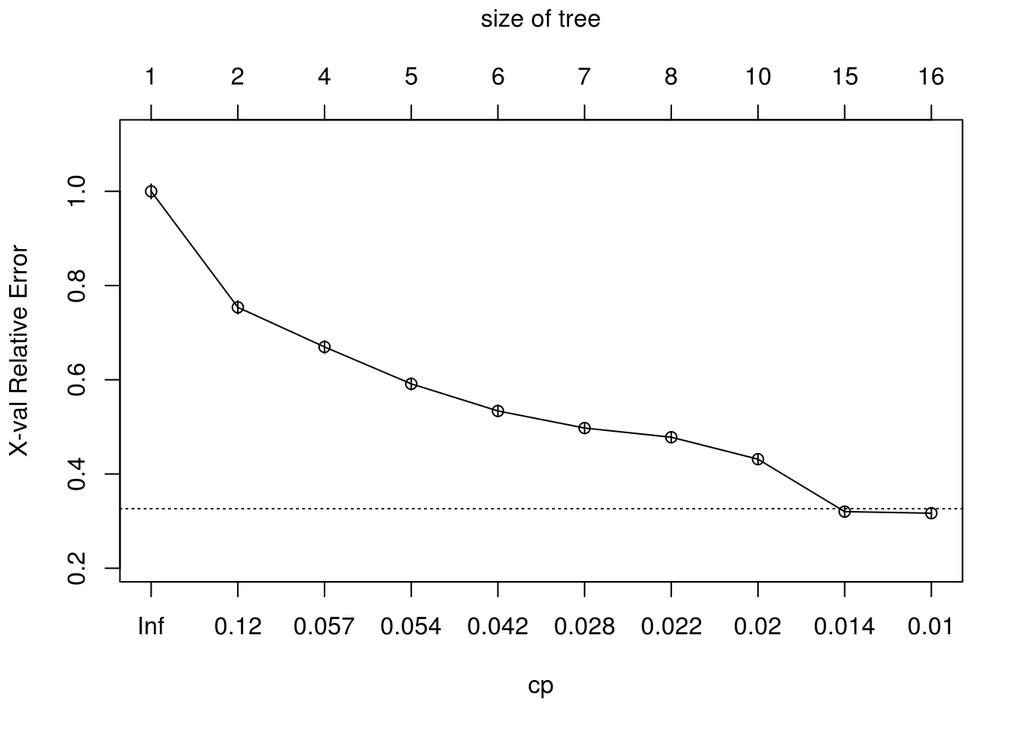

## Tree

### Summary of the tree

```
##
## Model formula:
## attentionName ~ boxHeight + boxRotation + boxArea + boxWidth +
##     widthHeightRatio + boxYcoordRel
##
## Fitted party:
## [1] root
## |   [2] boxYcoordRel >= 0.40429
## |   |   [3] boxRotation >= 7.93219: ipad (n = 1287, err = 11.4%)
## |   |   [4] boxRotation < 7.93219
## |   |   |   [5] boxYcoordRel >= 0.42093: ipad (n = 236, err = 14.0%)
## |   |   |   [6] boxYcoordRel < 0.42093
## |   |   |   |   [7] boxHeight < 44.19945: ipad (n = 196, err = 31.1%)
## |   |   |   |   [8] boxHeight >= 44.19945: tv (n = 467, err = 4.3%)
## |   [9] boxYcoordRel < 0.40429
## |   |   [10] boxYcoordRel >= 0.39773
## |   |   |   [11] boxHeight >= 34.2276
## |   |   |   |   [12] boxHeight < 45.5157
## |   |   |   |   |   [13] boxRotation >= 8.55052: ipad (n = 705, err = 12.5%)
## |   |   |   |   |   [14] boxRotation < 8.55052
## |   |   |   |   |   |   [15] boxYcoordRel >= 0.40059: ipad (n = 108, err = 5.6%)
## |   |   |   |   |   |   [16] boxYcoordRel < 0.40059: tv (n = 163, err = 8.6%)
## |   |   |   |   [17] boxHeight >= 45.5157: tv (n = 129, err = 7.0%)
## |   |   |   [18] boxHeight < 34.2276: tv (n = 2466, err = 12.0%)
## |   |   [19] boxYcoordRel < 0.39773
## |   |   |   [20] boxYcoordRel >= 0.39462
## |   |   |   |   [21] boxRotation < 26.41535
## |   |   |   |   |   [22] boxRotation >= 11.6244
## |   |   |   |   |   |   [23] boxHeight >= 31.61
## |   |   |   |   |   |   |   [24] boxHeight < 40.98905: ipad (n = 579, err = 16.1%)
## |   |   |   |   |   |   |   [25] boxHeight >= 40.98905: tv (n = 168, err = 8.9%)
## |   |   |   |   |   |   [26] boxHeight < 31.61
## |   |   |   |   |   |   |   [27] boxRotation < 12.8836: ipad (n = 35, err = 2.9%)
## |   |   |   |   |   |   |   [28] boxRotation >= 12.8836: tv (n = 396, err = 5.6%)
## |   |   |   |   |   [29] boxRotation < 11.6244: tv (n = 1749, err = 4.8%)
## |   |   |   |   [30] boxRotation >= 26.41535: tv (n = 2011, err = 0.9%)
## |   |   |   [31] boxYcoordRel < 0.39462: tv (n = 4103, err = 2.1%)
##
## Number of inner nodes:    15
## Number of terminal nodes: 16
```

### Visualisation of the tree

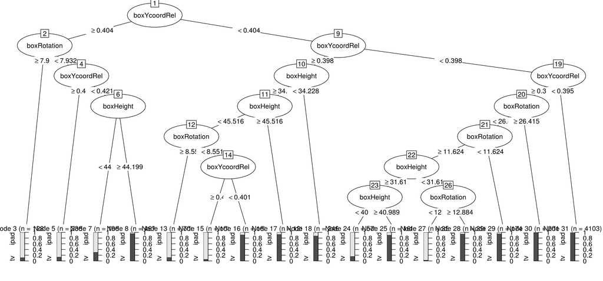

Tree classifier plot

## Error metrics analysis

Confusion matrix from the application of the tree predictor to the testing set of data.

```
##       predclass
##         ipad    tv
##   ipad 10125   998
##   tv    8485 11561
```

### Error metrics based on prediction of attention to the iPad.

True negatives: 11561

False negatives: 8485

True positives: 10125

False positives: 998

**Error-rate**: the proportion of the incorrectly classified examples -> (fp+fn)/(tp+tn+fp+tn)

**30.4244602**

**Accuracy**: the proportion of the correctly classified examples -> (tp+tn)/(tp+tn+fp+tn)

**69.5755398**

**Precision**: positive predicted value (PPV) -> tp/(tp+fp), a measure of exactness

**91.0276005**

**Recall/Sensitivity**: true positive recognition rate -> tp/(tp+fn), a measure of completeness

**54.4062332**

**Specificity**: true negative recognition rate -> tn/(tn+fp)

**92.0535074**

**F measure**: the balance between precision and recall -> 2*tp/(2*tp+fp+fn)

**68.1061447**

# ERROR MEASURES INLINE COPY

P06 **30.4244602** **69.5755398** **91.0276005** **54.4062332** **92.0535074** **68.1061447**

### Error metrics based on prediction of attention to the TV.

True negatives: 10125

False negatives: 998

True positives: 11561

False positives: 8485

**Error-rate**: the proportion of the incorrectly classified examples -> (fp+fn)/(tp+tn+fp+tn)

**30.4244602**

**Accuracy**: the proportion of the correctly classified examples -> (tp+tn)/(tp+tn+fp+tn)

**69.5755398**

As the number of instances of the response variable is not balanced (there are many more instances with false than true) the accuracy is not a good indicator. Other cost sensitive measures are reported here. -> cost sensitive measures

**Precision**: positive predicted value (PPV) -> tp/(tp+fp), a measure of exactness

**57.6723536**

**Recall/Sensitivity**: true positive recognition rate -> tp/(tp+fn), a measure of completeness

**92.0535074**

**Specificity**: true negative recognition rate -> tn/(tn+fp)

**54.4062332**

**F measure**: the balance between precision and recall -> 2*tp/(2*tp+fp+fn)

**70.9155038**